```python
import pandas as pd
import numpy as np
import matplotlib.pyplot as plt
```

# Question 1: Regression on Test Score Data

```python
data = pd.read_csv("https://vincentarelbundock.github.io/Rdatasets/csv/Ecdat/Caschool.csv")
data.head()
```

|  | Unnamed: 0 | distcod | county | district | grspan | enrltot | teachers | calwpct | mealpct | computer | testscr | compstu | expnstu | str | avginc | elpct | readscr | mathscr |
| --- | --- | --- | --- | --- | --- | --- | --- | --- | --- | --- | --- | --- | --- | --- | --- | --- | --- | --- |
| 0 | 1 | 75119 | Alameda | Sunol Glen Unified | KK-08 | 195 | 10.900000 | 0.510200 | 2.040800 | 67 | 690.799988 | 0.343590 | 6384.911133 | 17.889910 | 22.690001 | 0.000000 | 691.599976 | 690.000000 |
| 1 | 2 | 61499 | Butte | Manzanita Elementary | KK-08 | 240 | 11.150000 | 15.416700 | 47.916698 | 101 | 661.200012 | 0.420833 | 5099.380859 | 21.524664 | 9.824000 | 4.583333 | 660.500000 | 661.900024 |
| 2 | 3 | 61549 | Butte | Thermalito Union Elementary | KK-08 | 1550 | 82.900002 | 55.032299 | 76.322601 | 169 | 643.599976 | 0.109032 | 5501.954590 | 18.697226 | 8.978000 | 30.000002 | 636.299988 | 650.900024 |
| 3 | 4 | 61457 | Butte | Golden Feather Union Elementary | KK-08 | 243 | 14.000000 | 36.475399 | 77.049202 | 85 | 647.700012 | 0.349794 | 7101.831055 | 17.357143 | 8.978000 | 0.000000 | 651.900024 | 643.500000 |
| 4 | 5 | 61523 | Butte | Palermo Union Elementary | KK-08 | 1335 | 71.500000 | 33.108601 | 78.427002 | 171 | 640.849976 | 0.128090 | 5235.987793 | 18.671329 | 9.080333 | 13.857677 | 641.799988 | 639.900024 |

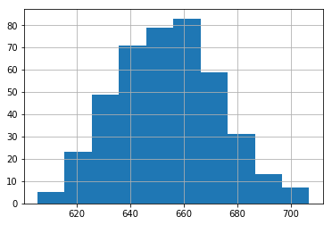

```python
Testscore = data["testscr"]
Testscore.hist()
```

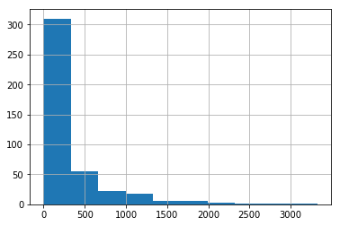

```python
ReadingScore = data["computer"]
ReadingScore.hist()
```

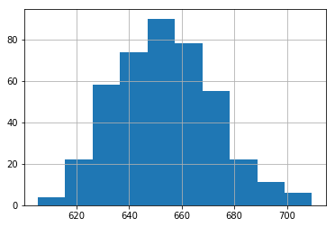

```python
MathScore = data["mathscr"]
MathScore.hist()
```

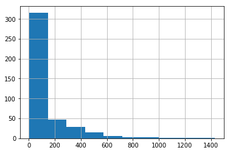

```python
Teacher = data["teachers"]
Teacher.hist()
```

```
Text(0,0.5,'Test Score')
```

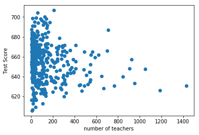

```python
1.2
plt.scatter(data["teachers"],data["testscr"])
plt.xlabel("number of teachers")
plt.ylabel("Test Score")
```

```
Text(0,0.5,'Test Score')
```

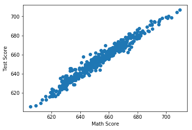

```python
plt.scatter(data["mathscr"],data["testscr"])
plt.xlabel("Math Score")
plt.ylabel("Test Score")
```

```
Text(0,0.5,'Test Score')
```

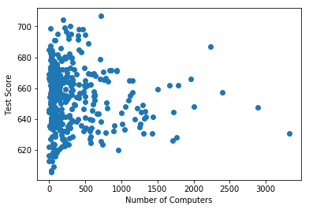

```python
plt.scatter(data["computer"],data["testscr"])
plt.xlabel("Number of Computers")
plt.ylabel("Test Score")
```

Split data in training and test set. Build models that evaluate the relationship between all available X variables in the California test dataset and the target variable. Evaluate KNN for regression, Linear Regression (OLS), Ridge, and Lasso using cross-validation with the default parameters. Does scaling the data with the StandardScaler help?

```python
#1.3 Train Test Split and Modelling
from sklearn.linear_model import LinearRegression
from sklearn.model_selection import train_test_split
import numpy as np

data_OLS = data.iloc[:, 5:]

y = data_OLS['testscr'] # median value of homes
X = data_OLS.loc[:, data_OLS.columns != 'testscr'].values

print(y[0:5])
data_OLS.head()
```

```
0    690.799988
1    661.200012
2    643.599976
3    647.700012
4    640.849976
Name: testscr, dtype: float64
```

|  | enrltot | teachers | calwpct | mealpct | computer | testscr | compstu | expnstu | str | avginc | elpct | readscr | mathscr |
| --- | --- | --- | --- | --- | --- | --- | --- | --- | --- | --- | --- | --- | --- |
| 0 | 195 | 10.900000 | 0.510200 | 2.040800 | 67 | 690.799988 | 0.343590 | 6384.911133 | 17.889910 | 22.690001 | 0.000000 | 691.599976 | 690.000000 |
| 1 | 240 | 11.150000 | 15.416700 | 47.916698 | 101 | 661.200012 | 0.420833 | 5099.380859 | 21.524664 | 9.824000 | 4.583333 | 660.500000 | 661.900024 |
| 2 | 1550 | 82.900002 | 55.032299 | 76.322601 | 169 | 643.599976 | 0.109032 | 5501.954590 | 18.697226 | 8.978000 | 30.000002 | 636.299988 | 650.900024 |
| 3 | 243 | 14.000000 | 36.475399 | 77.049202 | 85 | 647.700012 | 0.349794 | 7101.831055 | 17.357143 | 8.978000 | 0.000000 | 651.900024 | 643.500000 |
| 4 | 1335 | 71.500000 | 33.108601 | 78.427002 | 171 | 640.849976 | 0.128090 | 5235.987793 | 18.671329 | 9.080333 | 13.857677 | 641.799988 | 639.900024 |

```python
X_train, X_test, y_train, y_test = train_test_split(X, y, random_state=42)
lr = LinearRegression().fit(X_train, y_train)
```

# OLS Regression with Scikit Learn and StatsModel Library

```python
lr = LinearRegression().fit(X_train, y_train)
print("lr.coef_: {}".format(lr.coef_))
print("lr.intercept_: {}".format(lr.intercept_))
```

```
lr.coef_: [-4.97558624e-09  1.29658967e-07 -4.78317840e-08 -1.26500144e-07
 -1.63351423e-08  2.26488076e-05  1.18773393e-09  1.27261942e-06
  6.69317254e-08  2.29752413e-07  5.00000123e-01  4.99999864e-01]
lr.intercept_: -2.2207407823771064e-05
```

```python
print("Training set score: {:.2f}".format(lr.score(X_train, y_train)))
print("Test set score: {:.2f}".format(lr.score(X_test, y_test)))

#cross validation
from sklearn.model_selection import cross_val_score
print(np.mean(cross_val_score(LinearRegression(), X_train, y_train, cv=10, scoring="r2")))
```

```
Training set score: 1.00
Test set score: 1.00
0.9999999999982302
```

```python
#OLS Regression with the StatsModel Library
import statsmodels.api as sm
X_train_2 = sm.add_constant(X_train)
model = sm.OLS(y_train, X_train_2 ).fit()
model.summary()
```

OLS Regression Results

| Dep. Variable: | testscr | R-squared: | 1.000 |
| --- | --- | --- | --- |
| Model: | OLS | Adj. R-squared: | 1.000 |
| Method: | Least Squares | F-statistic: | 1.715e+13 |
| Date: | Wed, 27 Feb 2019 | Prob (F-statistic): | 0.00 |
| Time: | 22:12:15 | Log-Likelihood: | 2935.1 |
| No. Observations: | 315 | AIC: | -5844. |
| Df Residuals: | 302 | BIC: | -5795. |
| Df Model: | 12 |  |  |
| Covariance Type: | nonrobust |  |  |

|  | coef | std err | t | P>\|t\| | [0.025 | 0.975] |
| --- | --- | --- | --- | --- | --- | --- |
| const | -2.221e-05 | 0.000 | -0.196 | 0.845 | -0.000 | 0.000 |
| x1 | -4.976e-09 | 4.74e-09 | -1.049 | 0.295 | -1.43e-08 | 4.35e-09 |
| x2 | 1.297e-07 | 1.05e-07 | 1.230 | 0.220 | -7.78e-08 | 3.37e-07 |
| x3 | -4.783e-08 | 1.88e-07 | -0.255 | 0.799 | -4.18e-07 | 3.22e-07 |
| x4 | -1.265e-07 | 1.32e-07 | -0.956 | 0.340 | -3.87e-07 | 1.34e-07 |
| x5 | -1.634e-08 | 8.97e-09 | -1.820 | 0.070 | -3.4e-08 | 1.33e-09 |
| x6 | 2.265e-05 | 2.35e-05 | 0.965 | 0.335 | -2.35e-05 | 6.88e-05 |
| x7 | 1.188e-09 | 2.8e-09 | 0.425 | 0.671 | -4.31e-09 | 6.69e-09 |
| x8 | 1.273e-06 | 1.01e-06 | 1.256 | 0.210 | -7.21e-07 | 3.27e-06 |
| x9 | 6.693e-08 | 2.78e-07 | 0.241 | 0.810 | -4.8e-07 | 6.13e-07 |
| x10 | 2.298e-07 | 1.24e-07 | 1.848 | 0.066 | -1.49e-08 | 4.74e-07 |
| x11 | 0.5000 | 2.3e-07 | 2.17e+06 | 0.000 | 0.500 | 0.500 |
| x12 | 0.5000 | 1.88e-07 | 2.65e+06 | 0.000 | 0.500 | 0.500 |

| Omnibus: | 73.918 | Durbin-Watson: | 1.890 |
| --- | --- | --- | --- |
| Prob(Omnibus): | 0.000 | Jarque-Bera (JB): | 14.952 |
| Skew: | -0.108 | Prob(JB): | 0.000566 |
| Kurtosis: | 1.955 | Cond. No. | 5.88e+05 |

Warnings:  
[1] Standard Errors assume that the covariance matrix of the errors is correctly specified.  
[2] The condition number is large, 5.88e+05. This might indicate that there are  
strong multicollinearity or other numerical problems.

# Ridge Regression

```python
from sklearn.linear_model import Ridge
ridge = Ridge(alpha = 0.8).fit(X_train, y_train)
print("Training set score: {:.2f}".format(ridge.score(X_train, y_train)))
print("Test set score: {:.2f}".format(ridge.score(X_test, y_test)))

ridge.coef_
```

```
Training set score: 1.00
Test set score: 1.00
```

```
array([-1.94952925e-09, -2.20750393e-08, -1.99734495e-06, -8.73958270e-06,
        1.83683778e-08, -7.55744276e-06,  6.03005893e-08, -7.33443327e-06,
        1.02272433e-05, -5.03469125e-06,  4.99981977e-01,  4.99996041e-01])
```

# Lasso Regression

```python
from sklearn.linear_model import Lasso
lasso = Lasso().fit(X_train, y_train)
print("Training set score: {:.2f}".format(lasso.score(X_train, y_train)))
print("Test set score: {:.2f}".format(lasso.score(X_test, y_test)))
print("Number of features used: {}".format(np.sum(lasso.coef_ != 0)))

print("lasso coefficients: {}".format(lasso.coef_))
```

```
Training set score: 1.00
Test set score: 1.00
Number of features used: 6
lasso coefficients: [-3.97831807e-06  0.00000000e+00 -0.00000000e+00 -1.72574284e-03
  2.25783099e-05  0.00000000e+00  2.39999917e-05 -0.00000000e+00
  0.00000000e+00 -0.00000000e+00  4.97294837e-01  4.97454029e-01]
```

```python
#Lower Alpha and increase iteration to fit a more complex model
lasso_complex = Lasso(alpha=0.01, max_iter=100000).fit(X_train, y_train)
print("Training set score: {:.2f}".format(lasso_complex.score(X_train, y_train)))
print("Test set score: {:.2f}".format(lasso_complex.score(X_test, y_test)))
print("Number of features used: {}".format(np.sum(lasso_complex.coef_ != 0)))
```

```
Training set score: 1.00
Test set score: 1.00
Number of features used: 6
```

# KNN

```python
X_train_KNN, X_test_KNN, y_train_KNN, y_test_KNN = train_test_split(X, y)
```

```python
#Train model with K=5
from sklearn.neighbors import KNeighborsRegressor
knn = KNeighborsRegressor(n_neighbors=5)
knn.fit(X_train_KNN, y_train_KNN)
```

```
KNeighborsRegressor(algorithm='auto', leaf_size=30, metric='minkowski',
          metric_params=None, n_jobs=1, n_neighbors=5, p=2,
          weights='uniform')
```

```python
y_pred = knn.predict(X_test_KNN)
y_pred[:10]
#Accuracy
```

```
array([644.44001465, 643.49998779, 638.77001953, 644.10998535,
       649.80002441, 651.26999512, 648.45999756, 664.52999268,
       651.61998291, 642.91999512])
```

```python
#Scaling the data with standard scaler
from sklearn import preprocessing
import numpy as np
scaler_Testscr = preprocessing.StandardScaler().fit(X_train)
scaler_Testscr
scalerTest = scaler_Testscr.transform(X_train)
```

```python
#For Ridge Regression
X_train, X_test, y_train, y_test = train_test_split(X, y)
scaler = preprocessing.StandardScaler()
scaler.fit(X_train)
X_train_scaled = scaler.transform(X_train)
ridge = Ridge().fit(X_train_scaled, y_train)
X_test_scaled = scaler.transform(X_test)
ridge.score(X_test_scaled, y_test)
```

```
0.9999828071427286
```

```python
#For Lasso Regression
X_train, X_test, y_train, y_test = train_test_split(X, y)
scaler = preprocessing.StandardScaler()
scaler.fit(X_train)
X_train_scaled = scaler.transform(X_train)
lasso2 = Lasso().fit(X_train_scaled, y_train)
X_test_scaled = scaler.transform(X_test)
lasso2.score(X_test_scaled, y_test)
```

```
0.9970358079708884
```

According to our score result, scaling the data actually decreases the score marginally. Thus, it doesn't help

### 1.4

### Tune the parameters of the models where possible using GridSearchCV. Do the results improve?

```python
# For KNN
from sklearn.model_selection import GridSearchCV
import numpy as np

X_train_KNN, X_test_KNN, y_train_KNN, y_test_KNN = train_test_split(X, y)

X_train_KNN = X_train_KNN.astype(int)
y_train_KNN = y_train_KNN.astype(int)

param_grid = {'n_neighbors': np.arange(1, 15, 2)}

grid = GridSearchCV(KNeighborsClassifier(), param_grid=param_grid, cv=5)

grid.fit(X_train_KNN, y_train_KNN)

print("best mean cross-validation score: {:.3f}".format(grid.best_score_))
print("best parameters: {}".format(grid.best_params_))
```

```
best mean cross-validation score: 0.013
best parameters: {'n_neighbors': 1}
```

```python
results = pd.DataFrame(grid.cv_results_)
results
```

|  | mean_fit_time | std_fit_time | mean_score_time | std_score_time | param_n_neighbors | params | split0_test_score | split1_test_score | split2_test_score | split3_test_score | ... | mean_test_score | std_test_score | rank_test_score | split0_train_score | split1_train_score | split2_train_score | split3_train_score | split4_train_score | mean_train_score | std_train_score |
| --- | --- | --- | --- | --- | --- | --- | --- | --- | --- | --- | --- | --- | --- | --- | --- | --- | --- | --- | --- | --- | --- |
| 0 | 0.000592 | 0.000122 | 0.000974 | 0.000230 | 1 | {'n_neighbors': 1} | 0.009346 | 0.000000 | 0.017857 | 0.022727 | ... | 0.012698 | 0.009983 | 1 | 1.000000 | 1.000000 | 1.000000 | 1.000000 | 1.000000 | 1.000000 | 0.000000 |
| 1 | 0.000788 | 0.000474 | 0.001614 | 0.000663 | 3 | {'n_neighbors': 3} | 0.000000 | 0.012987 | 0.000000 | 0.000000 | ... | 0.003175 | 0.005581 | 6 | 0.346154 | 0.323529 | 0.343629 | 0.354244 | 0.330986 | 0.339708 | 0.011009 |
| 2 | 0.000534 | 0.000054 | 0.001379 | 0.000138 | 5 | {'n_neighbors': 5} | 0.000000 | 0.000000 | 0.000000 | 0.000000 | ... | 0.003175 | 0.009609 | 6 | 0.240385 | 0.214286 | 0.223938 | 0.184502 | 0.207746 | 0.214171 | 0.018461 |
| 3 | 0.000520 | 0.000049 | 0.001722 | 0.000312 | 7 | {'n_neighbors': 7} | 0.009346 | 0.000000 | 0.000000 | 0.000000 | ... | 0.009524 | 0.018671 | 4 | 0.177885 | 0.168067 | 0.181467 | 0.173432 | 0.140845 | 0.168339 | 0.014460 |
| 4 | 0.000541 | 0.000021 | 0.001546 | 0.000194 | 9 | {'n_neighbors': 9} | 0.009346 | 0.012987 | 0.000000 | 0.000000 | ... | 0.012698 | 0.017868 | 1 | 0.144231 | 0.134454 | 0.142857 | 0.158672 | 0.144366 | 0.144916 | 0.007793 |
| 5 | 0.000587 | 0.000100 | 0.001605 | 0.000177 | 11 | {'n_neighbors': 11} | 0.000000 | 0.012987 | 0.017857 | 0.022727 | ... | 0.012698 | 0.010546 | 1 | 0.129808 | 0.117647 | 0.123552 | 0.132841 | 0.137324 | 0.128234 | 0.006933 |
| 6 | 0.000556 | 0.000075 | 0.001693 | 0.000190 | 13 | {'n_neighbors': 13} | 0.000000 | 0.000000 | 0.017857 | 0.022727 | ... | 0.009524 | 0.011855 | 4 | 0.144231 | 0.109244 | 0.115830 | 0.103321 | 0.102113 | 0.114948 | 0.015432 |

7 rows × 21 columns

```python
#For Ridge Regressions

from sklearn.model_selection import GridSearchCV
import numpy as np

param_grid_ridge = {'alpha': [25,10,4,2,1.0,0.8,0.5,0.3,0.2,0.1,0.05,0.02,0.01]}
rdg_reg = Ridge()

grid_ridge = GridSearchCV(rdg_reg, param_grid=param_grid_ridge, cv=5)

grid_ridge.fit(X_train, y_train)

print("best mean cross-validation score: {:.3f}".format(grid_ridge.best_score_))
print("best parameters: {}".format(grid_ridge.best_params_))
```

```
best mean cross-validation score: 1.000
best parameters: {'alpha': 0.01}
```

```python
results_ridge = pd.DataFrame(grid_ridge.cv_results_)
results_ridge
```

|  | mean_fit_time | std_fit_time | mean_score_time | std_score_time | param_alpha | params | split0_test_score | split1_test_score | split2_test_score | split3_test_score | ... | mean_test_score | std_test_score | rank_test_score | split0_train_score | split1_train_score | split2_train_score | split3_train_score | split4_train_score | mean_train_score | std_train_score |
| --- | --- | --- | --- | --- | --- | --- | --- | --- | --- | --- | --- | --- | --- | --- | --- | --- | --- | --- | --- | --- | --- |
| 0 | 0.004316 | 0.005444 | 0.001583 | 0.002379 | 25 | {'alpha': 25} | 1.0 | 1.0 | 1.0 | 1.0 | ... | 1.0 | 2.815813e-08 | 13 | 1.0 | 1.0 | 1.0 | 1.0 | 1.0 | 1.0 | 4.758846e-09 |
| 1 | 0.000839 | 0.000182 | 0.000268 | 0.000049 | 10 | {'alpha': 10} | 1.0 | 1.0 | 1.0 | 1.0 | ... | 1.0 | 4.570483e-09 | 12 | 1.0 | 1.0 | 1.0 | 1.0 | 1.0 | 1.0 | 7.701204e-10 |
| 2 | 0.001040 | 0.000144 | 0.000409 | 0.000082 | 4 | {'alpha': 4} | 1.0 | 1.0 | 1.0 | 1.0 | ... | 1.0 | 7.415324e-10 | 11 | 1.0 | 1.0 | 1.0 | 1.0 | 1.0 | 1.0 | 1.238571e-10 |
| 3 | 0.001027 | 0.000215 | 0.000417 | 0.000176 | 2 | {'alpha': 2} | 1.0 | 1.0 | 1.0 | 1.0 | ... | 1.0 | 1.882722e-10 | 10 | 1.0 | 1.0 | 1.0 | 1.0 | 1.0 | 1.0 | 3.105879e-11 |
| 4 | 0.001347 | 0.000629 | 0.000391 | 0.000244 | 1 | {'alpha': 1.0} | 1.0 | 1.0 | 1.0 | 1.0 | ... | 1.0 | 4.818024e-11 | 9 | 1.0 | 1.0 | 1.0 | 1.0 | 1.0 | 1.0 | 7.800415e-12 |
| 5 | 0.000592 | 0.000051 | 0.000219 | 0.000030 | 0.8 | {'alpha': 0.8} | 1.0 | 1.0 | 1.0 | 1.0 | ... | 1.0 | 3.113889e-11 | 8 | 1.0 | 1.0 | 1.0 | 1.0 | 1.0 | 1.0 | 5.003038e-12 |
| 6 | 0.000636 | 0.000113 | 0.000226 | 0.000027 | 0.5 | {'alpha': 0.5} | 1.0 | 1.0 | 1.0 | 1.0 | ... | 1.0 | 1.248463e-11 | 7 | 1.0 | 1.0 | 1.0 | 1.0 | 1.0 | 1.0 | 1.966268e-12 |
| 7 | 0.000622 | 0.000130 | 0.000215 | 0.000026 | 0.3 | {'alpha': 0.3} | 1.0 | 1.0 | 1.0 | 1.0 | ... | 1.0 | 4.695734e-12 | 6 | 1.0 | 1.0 | 1.0 | 1.0 | 1.0 | 1.0 | 7.151745e-13 |
| 8 | 0.000577 | 0.000024 | 0.000210 | 0.000011 | 0.2 | {'alpha': 0.2} | 1.0 | 1.0 | 1.0 | 1.0 | ... | 1.0 | 2.218566e-12 | 5 | 1.0 | 1.0 | 1.0 | 1.0 | 1.0 | 1.0 | 3.231849e-13 |
| 9 | 0.000711 | 0.000126 | 0.000251 | 0.000042 | 0.1 | {'alpha': 0.1} | 1.0 | 1.0 | 1.0 | 1.0 | ... | 1.0 | 7.067438e-13 | 4 | 1.0 | 1.0 | 1.0 | 1.0 | 1.0 | 1.0 | 9.244045e-14 |
| 10 | 0.000561 | 0.000033 | 0.000201 | 0.000004 | 0.05 | {'alpha': 0.05} | 1.0 | 1.0 | 1.0 | 1.0 | ... | 1.0 | 3.104308e-13 | 3 | 1.0 | 1.0 | 1.0 | 1.0 | 1.0 | 1.0 | 4.731408e-14 |
| 11 | 0.000642 | 0.000109 | 0.000275 | 0.000065 | 0.02 | {'alpha': 0.02} | 1.0 | 1.0 | 1.0 | 1.0 | ... | 1.0 | 1.689357e-13 | 2 | 1.0 | 1.0 | 1.0 | 1.0 | 1.0 | 1.0 | 4.206143e-14 |
| 12 | 0.000560 | 0.000042 | 0.000209 | 0.000017 | 0.01 | {'alpha': 0.01} | 1.0 | 1.0 | 1.0 | 1.0 | ... | 1.0 | 1.331244e-13 | 1 | 1.0 | 1.0 | 1.0 | 1.0 | 1.0 | 1.0 | 4.184710e-14 |

13 rows × 21 columns

```python
#For Lasso Regression

param_grid_lasso = {'alpha': [25,10,4,2,1.0,0.8,0.5,0.3,0.2,0.1,0.05,0.02,0.01]}
lso_reg = Lasso()

grid_lasso = GridSearchCV(lso_reg, param_grid=param_grid_lasso, cv=5)

grid_lasso.fit(X_train, y_train)

print("best mean cross-validation score: {:.3f}".format(grid_lasso.best_score_))
print("best parameters: {}".format(grid_lasso.best_params_))
```

```
best mean cross-validation score: 1.000
best parameters: {'alpha': 0.05}
```

```python
results_lasso = pd.DataFrame(grid_lasso.cv_results_)
results_lasso
```

|  | mean_fit_time | std_fit_time | mean_score_time | std_score_time | param_alpha | params | split0_test_score | split1_test_score | split2_test_score | split3_test_score | ... | mean_test_score | std_test_score | rank_test_score | split0_train_score | split1_train_score | split2_train_score | split3_train_score | split4_train_score | mean_train_score | std_train_score |
| --- | --- | --- | --- | --- | --- | --- | --- | --- | --- | --- | --- | --- | --- | --- | --- | --- | --- | --- | --- | --- | --- |
| 0 | 0.001854 | 0.000791 | 0.000345 | 0.000052 | 25 | {'alpha': 25} | 0.993482 | 0.992988 | 0.991605 | 0.994954 | ... | 0.993098 | 1.116812e-03 | 13 | 0.993721 | 0.993746 | 0.993252 | 0.993989 | 0.994052 | 0.993752 | 2.819254e-04 |
| 1 | 0.001328 | 0.000599 | 0.000289 | 0.000047 | 10 | {'alpha': 10} | 0.998957 | 0.998879 | 0.998657 | 0.999193 | ... | 0.998896 | 1.786383e-04 | 12 | 0.998996 | 0.999000 | 0.998921 | 0.999038 | 0.999049 | 0.999001 | 4.510588e-05 |
| 2 | 0.000836 | 0.000255 | 0.000272 | 0.000028 | 4 | {'alpha': 4} | 0.999833 | 0.999821 | 0.999785 | 0.999871 | ... | 0.999823 | 2.854776e-05 | 11 | 0.999839 | 0.999840 | 0.999827 | 0.999846 | 0.999848 | 0.999840 | 7.204445e-06 |
| 3 | 0.000957 | 0.000360 | 0.000254 | 0.000019 | 2 | {'alpha': 2} | 0.999958 | 0.999955 | 0.999946 | 0.999968 | ... | 0.999956 | 7.154200e-06 | 10 | 0.999960 | 0.999960 | 0.999957 | 0.999962 | 0.999962 | 0.999960 | 1.818791e-06 |
| 4 | 0.000713 | 0.000079 | 0.000277 | 0.000059 | 1 | {'alpha': 1.0} | 0.999990 | 0.999989 | 0.999986 | 0.999992 | ... | 0.999989 | 1.833423e-06 | 9 | 0.999990 | 0.999990 | 0.999989 | 0.999990 | 0.999991 | 0.999990 | 5.003275e-07 |
| 5 | 0.000645 | 0.000062 | 0.000224 | 0.000014 | 0.8 | {'alpha': 0.8} | 0.999993 | 0.999993 | 0.999991 | 0.999995 | ... | 0.999993 | 1.180074e-06 | 8 | 0.999994 | 0.999994 | 0.999993 | 0.999994 | 0.999994 | 0.999994 | 3.291355e-07 |
| 6 | 0.000748 | 0.000267 | 0.000265 | 0.000085 | 0.5 | {'alpha': 0.5} | 0.999997 | 0.999997 | 0.999997 | 0.999998 | ... | 0.999997 | 4.623662e-07 | 7 | 0.999998 | 0.999998 | 0.999997 | 0.999998 | 0.999998 | 0.999998 | 1.334834e-07 |
| 7 | 0.000968 | 0.000450 | 0.000450 | 0.000356 | 0.3 | {'alpha': 0.3} | 0.999999 | 0.999999 | 0.999999 | 0.999999 | ... | 0.999999 | 1.655546e-07 | 6 | 0.999999 | 0.999999 | 0.999999 | 0.999999 | 0.999999 | 0.999999 | 4.892705e-08 |
| 8 | 0.000758 | 0.000117 | 0.000462 | 0.000347 | 0.2 | {'alpha': 0.2} | 1.000000 | 1.000000 | 0.999999 | 1.000000 | ... | 1.000000 | 7.361682e-08 | 5 | 1.000000 | 1.000000 | 1.000000 | 1.000000 | 1.000000 | 1.000000 | 1.886533e-08 |
| 9 | 0.000770 | 0.000161 | 0.000228 | 0.000046 | 0.1 | {'alpha': 0.1} | 1.000000 | 1.000000 | 1.000000 | 1.000000 | ... | 1.000000 | 1.851109e-08 | 2 | 1.000000 | 1.000000 | 1.000000 | 1.000000 | 1.000000 | 1.000000 | 4.528202e-09 |
| 10 | 0.000810 | 0.000121 | 0.000210 | 0.000013 | 0.05 | {'alpha': 0.05} | 1.000000 | 1.000000 | 1.000000 | 1.000000 | ... | 1.000000 | 4.705981e-09 | 1 | 1.000000 | 1.000000 | 1.000000 | 1.000000 | 1.000000 | 1.000000 | 1.120797e-09 |
| 11 | 0.000518 | 0.000005 | 0.000214 | 0.000019 | 0.02 | {'alpha': 0.02} | 1.000000 | 1.000000 | 1.000000 | 1.000000 | ... | 1.000000 | 1.436413e-07 | 4 | 1.000000 | 1.000000 | 1.000000 | 1.000000 | 1.000000 | 1.000000 | 5.206923e-08 |
| 12 | 0.000604 | 0.000182 | 0.000221 | 0.000042 | 0.01 | {'alpha': 0.01} | 1.000000 | 1.000000 | 1.000000 | 1.000000 | ... | 1.000000 | 1.410419e-07 | 3 | 1.000000 | 1.000000 | 1.000000 | 1.000000 | 1.000000 | 1.000000 | 5.008487e-08 |

13 rows × 21 columns

### 1.5

### Compare the coefficients of your two best linear models (not knn), do they agree on which features are important?

```python
print(ridge.coef_)
print(lasso.coef_)
```

[output not shown]

### 1.6

### Discuss which final model you would choose to predict new data

I would personally go with the lasso model because the lasso model performs parameter shrinkage and variable selections automatically. Thus, I have an easier time determining which variables have an effect on the test scores. Moreover, this dataset has only a few variables with medium to large effect, thus, using lassos to wield out irrelevant variables seem reasonable compare to using ridge regression.

# QUESTION 2

```python
red = pd.read_csv("/Users/guan-hunglai/Desktop/Machine Learning/HW 2/winequality-red.csv", sep = ";")
red.head()
white = pd.read_csv("/Users/guan-hunglai/Desktop/Machine Learning/HW 2/winequality-white.csv", sep = ";")
white.head()
```

|  | fixed acidity | volatile acidity | citric acid | residual sugar | chlorides | free sulfur dioxide | total sulfur dioxide | density | pH | sulphates | alcohol | quality |
| --- | --- | --- | --- | --- | --- | --- | --- | --- | --- | --- | --- | --- |
| 0 | 7.0 | 0.27 | 0.36 | 20.7 | 0.045 | 45.0 | 170.0 | 1.0010 | 3.00 | 0.45 | 8.8 | 6 |
| 1 | 6.3 | 0.30 | 0.34 | 1.6 | 0.049 | 14.0 | 132.0 | 0.9940 | 3.30 | 0.49 | 9.5 | 6 |
| 2 | 8.1 | 0.28 | 0.40 | 6.9 | 0.050 | 30.0 | 97.0 | 0.9951 | 3.26 | 0.44 | 10.1 | 6 |
| 3 | 7.2 | 0.23 | 0.32 | 8.5 | 0.058 | 47.0 | 186.0 | 0.9956 | 3.19 | 0.40 | 9.9 | 6 |
| 4 | 7.2 | 0.23 | 0.32 | 8.5 | 0.058 | 47.0 | 186.0 | 0.9956 | 3.19 | 0.40 | 9.9 | 6 |

```python
red['WineType'] = 1
red.head()
white['WineType'] = 0
white.head()
```

|  | fixed acidity | volatile acidity | citric acid | residual sugar | chlorides | free sulfur dioxide | total sulfur dioxide | density | pH | sulphates | alcohol | quality | WineType |
| --- | --- | --- | --- | --- | --- | --- | --- | --- | --- | --- | --- | --- | --- |
| 0 | 7.0 | 0.27 | 0.36 | 20.7 | 0.045 | 45.0 | 170.0 | 1.0010 | 3.00 | 0.45 | 8.8 | 6 | 0 |
| 1 | 6.3 | 0.30 | 0.34 | 1.6 | 0.049 | 14.0 | 132.0 | 0.9940 | 3.30 | 0.49 | 9.5 | 6 | 0 |
| 2 | 8.1 | 0.28 | 0.40 | 6.9 | 0.050 | 30.0 | 97.0 | 0.9951 | 3.26 | 0.44 | 10.1 | 6 | 0 |
| 3 | 7.2 | 0.23 | 0.32 | 8.5 | 0.058 | 47.0 | 186.0 | 0.9956 | 3.19 | 0.40 | 9.9 | 6 | 0 |
| 4 | 7.2 | 0.23 | 0.32 | 8.5 | 0.058 | 47.0 | 186.0 | 0.9956 | 3.19 | 0.40 | 9.9 | 6 | 0 |

```python
Wine = red.append(white)
Wine.head()
```

|  | fixed acidity | volatile acidity | citric acid | residual sugar | chlorides | free sulfur dioxide | total sulfur dioxide | density | pH | sulphates | alcohol | quality | WineType |
| --- | --- | --- | --- | --- | --- | --- | --- | --- | --- | --- | --- | --- | --- |
| 0 | 7.4 | 0.70 | 0.00 | 1.9 | 0.076 | 11.0 | 34.0 | 0.9978 | 3.51 | 0.56 | 9.4 | 5 | 1 |
| 1 | 7.8 | 0.88 | 0.00 | 2.6 | 0.098 | 25.0 | 67.0 | 0.9968 | 3.20 | 0.68 | 9.8 | 5 | 1 |
| 2 | 7.8 | 0.76 | 0.04 | 2.3 | 0.092 | 15.0 | 54.0 | 0.9970 | 3.26 | 0.65 | 9.8 | 5 | 1 |
| 3 | 11.2 | 0.28 | 0.56 | 1.9 | 0.075 | 17.0 | 60.0 | 0.9980 | 3.16 | 0.58 | 9.8 | 6 | 1 |
| 4 | 7.4 | 0.70 | 0.00 | 1.9 | 0.076 | 11.0 | 34.0 | 0.9978 | 3.51 | 0.56 | 9.4 | 5 | 1 |

### 2.1 Visualize the univariate distribution of the target feature and each of the three explanatory variables that you think are likely to have a relationship with the target feature.

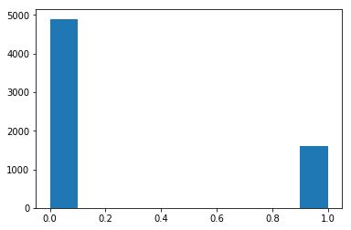

```python
plt.hist(Wine["WineType"])
```

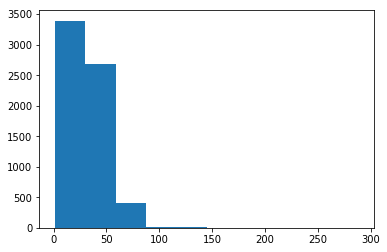

```python
plt.hist(Wine["free sulfur dioxide"])
```

```python
Wine["pH"].hist()
```

[output not shown]

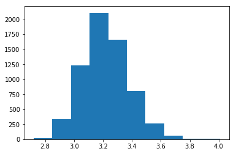

```python
plt.hist(Wine["pH"])
```

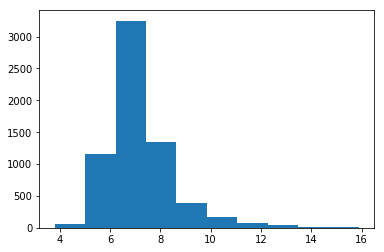

```python
plt.hist(Wine["fixed acidity"])
```

### 2.2 Split data into training and test set. Build models that evaluate the relationship between all available X variables in the dataset and the target variable. Evaluate Logistic Regression, Penalized Logistic Regression, and KNN for classification using cross-validation. How different are the results? How does scaling the data with StandardScaler influence the results?

```python
#Training-Test Split
Wine_y = Wine['WineType']
Wine_X = Wine.loc[:, Wine.columns != 'WineType']

from sklearn.model_selection import train_test_split

X_train_Wine, X_test_Wine, y_train_Wine, y_test_Wine = train_test_split(
    Wine_X, Wine_y, random_state=42)
```

```python
#Logistic Regression
from sklearn.linear_model import LogisticRegression

logreg = LogisticRegression(C=1e90).fit(X_train_Wine, y_train_Wine)

print("logreg .coef_: {}".format(logreg .coef_))


print("Training set score: {:.3f}".format(logreg.score(X_train_Wine, y_train_Wine)))
print("Test set score: {:.3f}".format(logreg.score(X_test_Wine, y_test_Wine)))


predicted_vals = logreg.predict(X_test_Wine)
print("logreg.predict: {}".format(predicted_vals))

logreg
```

```
logreg .coef_: [[  1.29612726  14.91140393   0.2540755   -0.24807206  20.89603882
    0.05491779  -0.07247028 -17.48028719   7.82442333  10.75232234
   -0.73467275   0.25639556]]
Training set score: 0.990
Test set score: 0.987
logreg.predict: [0 0 0 ... 0 0 1]
```

```
LogisticRegression(C=1e+90, class_weight=None, dual=False, fit_intercept=True,
          intercept_scaling=1, max_iter=100, multi_class='ovr', n_jobs=1,
          penalty='l2', random_state=None, solver='liblinear', tol=0.0001,
          verbose=0, warm_start=False)
```

```python
#Penalized Logistic Regression
logreg_P = LogisticRegression(C=0.1).fit(X_train_Wine, y_train_Wine)

print("logreg .coef_: {}".format(logreg_P .coef_))


print("Training set score: {:.3f}".format(logreg_P.score(X_train_Wine, y_train_Wine)))
print("Test set score: {:.3f}".format(logreg_P.score(X_test_Wine, y_test_Wine)))


predicted_vals = logreg_P.predict(X_test_Wine)
print("logreg.predict: {}".format(predicted_vals))
```

```
logreg .coef_: [[ 0.71694872  3.28066458 -0.81866024 -0.18169876  0.5253138   0.03705587
  -0.06030958 -0.19461939  1.69459331  2.26489137 -0.72432375 -0.14616984]]
Training set score: 0.969
Test set score: 0.964
logreg.predict: [0 0 0 ... 0 0 1]
```

```python
#KNN
from sklearn.neighbors import KNeighborsClassifier
knn_Wine = KNeighborsClassifier(n_neighbors=5)
knn_Wine.fit(X_train_Wine, y_train_Wine)
```

```
KNeighborsClassifier(algorithm='auto', leaf_size=30, metric='minkowski',
           metric_params=None, n_jobs=1, n_neighbors=5, p=2,
           weights='uniform')
```

```python
y_pred_Wine = knn_Wine.predict(X_test_Wine)
y_pred_Wine
```

```
array([0, 0, 0, ..., 0, 1, 0])
```

```python
#Scaling the data with standard scaler
from sklearn import preprocessing
import numpy as np
scaler = preprocessing.StandardScaler().fit(X_train_Wine)
scaler
scaler.transform(X_train_Wine)
```

```
array([[-0.31821297, -0.66625569,  0.50352905, ...,  0.71934822,
        -0.24884506,  0.21389629],
       [ 0.06795127,  1.89246867, -0.81494451, ...,  0.31994866,
        -1.09219203,  0.21389629],
       [-0.16374727, -0.0642029 ,  3.20986952, ...,  0.12024889,
         0.42583252,  0.21389629],
       ...,
       [ 0.37688267, -0.48563985, -0.12101106, ..., -0.41228385,
         0.25716313,  0.21389629],
       [-0.78161006, -0.78666625, -0.25979775, ...,  3.64827827,
         1.39568154,  1.36158651],
       [ 1.3809097 , -0.60605041,  1.26685585, ..., -1.27764955,
         1.60651828,  0.21389629]])
```

### 2.3 Parameters Tuning with GridSearchCV

```python
from sklearn.model_selection import GridSearchCV
import numpy as np
```

```python
from sklearn.model_selection import cross_val_score
from sklearn.model_selection import RepeatedKFold
from sklearn.model_selection import StratifiedKFold
from sklearn.model_selection import KFold
import random
random.seed(1996)
```

```python
kfold = KFold(n_splits=10)
random.seed(1996)
skfold = StratifiedKFold(n_splits=10, shuffle=True)
print("KFold:\n{}".format(
cross_val_score(KNeighborsClassifier(), Wine_X, Wine_y, cv=kfold)))

print("StratifiedKFold:\n{}".format(
cross_val_score(KNeighborsClassifier(n_neighbors=5), Wine_X, Wine_y, cv=skfold)))
```

```
KFold:
[0.76153846 0.82       0.90769231 0.95692308 0.96307692 0.96769231
 0.96923077 0.96456086 0.9614792  0.97072419]
StratifiedKFold:
[0.94307692 0.94769231 0.95076923 0.95076923 0.93538462 0.94769231
 0.93692308 0.95076923 0.93990755 0.92901235]
```

```python
X_train_Wine, X_test_Wine, y_train_Wine, y_test_Wine = train_test_split(
    Wine_X, Wine_y, stratify = Wine_y)
```

```python
param_grid = {'n_neighbors': np.arange(1, 15, 2)}

grid = GridSearchCV(KNeighborsClassifier(), param_grid=param_grid, cv=skfold)

grid.fit(X_train_Wine, y_train_Wine)

print("best mean cross-validation score: {:.3f}".format(grid.best_score_))
print("best parameters: {}".format(grid.best_params_))
print("test-set score: {:.3f}".format(grid.score(X_test_Wine, y_test_Wine)))
```

```
best mean cross-validation score: 0.943
best parameters: {'n_neighbors': 1}
test-set score: 0.956
```

```python
#View Tuned Results for KNN
results_Wine = pd.DataFrame(grid.cv_results_)
results_Wine
```

|  | mean_fit_time | std_fit_time | mean_score_time | std_score_time | param_n_neighbors | params | split0_test_score | split1_test_score | split2_test_score | split3_test_score | ... | split2_train_score | split3_train_score | split4_train_score | split5_train_score | split6_train_score | split7_train_score | split8_train_score | split9_train_score | mean_train_score | std_train_score |
| --- | --- | --- | --- | --- | --- | --- | --- | --- | --- | --- | --- | --- | --- | --- | --- | --- | --- | --- | --- | --- | --- |
| 0 | 0.004734 | 0.000839 | 0.003319 | 0.000566 | 1 | {'n_neighbors': 1} | 0.952869 | 0.948770 | 0.932377 | 0.944559 | ... | 0.999772 | 1.000000 | 0.999772 | 0.999772 | 1.000000 | 0.999772 | 0.999772 | 0.999772 | 0.999818 | 0.000091 |
| 1 | 0.004215 | 0.000717 | 0.003256 | 0.000432 | 3 | {'n_neighbors': 3} | 0.940574 | 0.932377 | 0.934426 | 0.952772 | ... | 0.968522 | 0.968073 | 0.966249 | 0.966477 | 0.968073 | 0.967389 | 0.969669 | 0.967624 | 0.967364 | 0.001219 |
| 2 | 0.003701 | 0.000403 | 0.003281 | 0.000240 | 5 | {'n_neighbors': 5} | 0.948770 | 0.926230 | 0.940574 | 0.958932 | ... | 0.954836 | 0.956899 | 0.954162 | 0.955302 | 0.957583 | 0.954390 | 0.957127 | 0.955768 | 0.955505 | 0.001258 |
| 3 | 0.003885 | 0.000534 | 0.003804 | 0.000410 | 7 | {'n_neighbors': 7} | 0.948770 | 0.922131 | 0.940574 | 0.952772 | ... | 0.948449 | 0.949829 | 0.948233 | 0.950741 | 0.948689 | 0.946180 | 0.950057 | 0.948016 | 0.948755 | 0.001395 |
| 4 | 0.004148 | 0.000811 | 0.004692 | 0.002256 | 9 | {'n_neighbors': 9} | 0.956967 | 0.922131 | 0.938525 | 0.944559 | ... | 0.942974 | 0.943216 | 0.941619 | 0.945952 | 0.944356 | 0.943444 | 0.947092 | 0.944368 | 0.943965 | 0.001559 |
| 5 | 0.004422 | 0.001448 | 0.004819 | 0.001596 | 11 | {'n_neighbors': 11} | 0.954918 | 0.915984 | 0.940574 | 0.944559 | ... | 0.940009 | 0.940023 | 0.940707 | 0.941391 | 0.938198 | 0.939567 | 0.941619 | 0.940720 | 0.940659 | 0.001190 |
| 6 | 0.004411 | 0.000604 | 0.004891 | 0.000724 | 13 | {'n_neighbors': 13} | 0.950820 | 0.915984 | 0.940574 | 0.942505 | ... | 0.936359 | 0.938198 | 0.937058 | 0.938198 | 0.937742 | 0.935006 | 0.938198 | 0.938212 | 0.937557 | 0.001298 |

7 rows × 31 columns

```python
#For Logistic Regression

from sklearn.model_selection import GridSearchCV
import numpy as np

param_grid_Logistic = {'C': [25,10,4,2,1.0,0.8,0.5,0.3,0.2,0.1,0.05,0.02,0.01]}
logistic = LogisticRegression()

grid_log = GridSearchCV(logistic, param_grid=param_grid_Logistic, cv=5)

grid_log.fit(X_train_Wine, y_train_Wine)

print("best mean cross-validation score: {:.3f}".format(grid_log.best_score_))
print("best parameters: {}".format(grid_log.best_params_))
```

```
best mean cross-validation score: 0.987
best parameters: {'C': 25}
```

```python
#View Tuned Results for Logistic Regression
results_Wine_log = pd.DataFrame(grid_log.cv_results_)
results_Wine_log
```

|  | mean_fit_time | std_fit_time | mean_score_time | std_score_time | param_C | params | split0_test_score | split1_test_score | split2_test_score | split3_test_score | ... | mean_test_score | std_test_score | rank_test_score | split0_train_score | split1_train_score | split2_train_score | split3_train_score | split4_train_score | mean_train_score | std_train_score |
| --- | --- | --- | --- | --- | --- | --- | --- | --- | --- | --- | --- | --- | --- | --- | --- | --- | --- | --- | --- | --- | --- |
| 0 | 0.038286 | 0.011519 | 0.000698 | 0.000200 | 25 | {'C': 25} | 0.988718 | 0.990769 | 0.988718 | 0.981520 | ... | 0.987274 | 0.003159 | 1 | 0.988709 | 0.987683 | 0.988453 | 0.989995 | 0.988459 | 0.988660 | 0.000751 |
| 1 | 0.031363 | 0.004253 | 0.000870 | 0.000125 | 10 | {'C': 10} | 0.988718 | 0.987692 | 0.987692 | 0.983573 | ... | 0.986658 | 0.001844 | 2 | 0.987939 | 0.986400 | 0.988453 | 0.988456 | 0.988202 | 0.987890 | 0.000769 |
| 2 | 0.035983 | 0.005415 | 0.001064 | 0.000180 | 4 | {'C': 4} | 0.987692 | 0.986667 | 0.986667 | 0.980493 | ... | 0.985016 | 0.002653 | 3 | 0.985117 | 0.985630 | 0.985887 | 0.986403 | 0.986407 | 0.985889 | 0.000489 |
| 3 | 0.028328 | 0.003830 | 0.000815 | 0.000177 | 2 | {'C': 2} | 0.987692 | 0.983590 | 0.985641 | 0.978439 | ... | 0.983990 | 0.003090 | 4 | 0.985373 | 0.983577 | 0.984347 | 0.985377 | 0.985894 | 0.984914 | 0.000836 |
| 4 | 0.024034 | 0.002756 | 0.000838 | 0.000178 | 1 | {'C': 1.0} | 0.986667 | 0.982564 | 0.986667 | 0.976386 | ... | 0.983374 | 0.003811 | 5 | 0.983064 | 0.983321 | 0.982551 | 0.984094 | 0.984098 | 0.983426 | 0.000601 |
| 5 | 0.028715 | 0.002304 | 0.000810 | 0.000136 | 0.8 | {'C': 0.8} | 0.983590 | 0.981538 | 0.986667 | 0.976386 | ... | 0.982348 | 0.003401 | 6 | 0.983064 | 0.982037 | 0.982037 | 0.983838 | 0.983073 | 0.982810 | 0.000690 |
| 6 | 0.033745 | 0.002913 | 0.001202 | 0.000224 | 0.5 | {'C': 0.5} | 0.980513 | 0.979487 | 0.982564 | 0.971253 | ... | 0.979269 | 0.004179 | 7 | 0.979985 | 0.978958 | 0.980241 | 0.980246 | 0.980251 | 0.979936 | 0.000499 |
| 7 | 0.031438 | 0.003676 | 0.000984 | 0.000198 | 0.3 | {'C': 0.3} | 0.975385 | 0.974359 | 0.975385 | 0.970226 | ... | 0.975164 | 0.003264 | 8 | 0.976135 | 0.975879 | 0.976135 | 0.976398 | 0.974865 | 0.975883 | 0.000535 |
| 8 | 0.025450 | 0.001567 | 0.001072 | 0.000173 | 0.2 | {'C': 0.2} | 0.973333 | 0.971282 | 0.971282 | 0.968172 | ... | 0.972496 | 0.003387 | 9 | 0.972800 | 0.974596 | 0.973569 | 0.973320 | 0.972044 | 0.973266 | 0.000845 |
| 9 | 0.020067 | 0.001541 | 0.000725 | 0.000114 | 0.1 | {'C': 0.1} | 0.968205 | 0.965128 | 0.967179 | 0.963039 | ... | 0.967365 | 0.003446 | 10 | 0.967411 | 0.968181 | 0.968437 | 0.968189 | 0.966658 | 0.967775 | 0.000656 |
| 10 | 0.019612 | 0.000485 | 0.000724 | 0.000155 | 0.05 | {'C': 0.05} | 0.960000 | 0.958974 | 0.961026 | 0.956879 | ... | 0.960796 | 0.003440 | 11 | 0.960996 | 0.960482 | 0.960482 | 0.961006 | 0.959220 | 0.960437 | 0.000651 |
| 11 | 0.019209 | 0.002871 | 0.000888 | 0.000170 | 0.02 | {'C': 0.02} | 0.948718 | 0.955897 | 0.955897 | 0.942505 | ... | 0.952176 | 0.005752 | 12 | 0.953811 | 0.952014 | 0.952014 | 0.954849 | 0.951270 | 0.952792 | 0.001326 |
| 12 | 0.020120 | 0.002988 | 0.001062 | 0.000279 | 0.01 | {'C': 0.01} | 0.944615 | 0.948718 | 0.955897 | 0.938398 | ... | 0.948892 | 0.006935 | 13 | 0.949705 | 0.948935 | 0.947395 | 0.951514 | 0.947935 | 0.949097 | 0.001448 |

13 rows × 21 columns

### 2.4 Change the cross-validation strategy in GridSearchCV from ‘stratified k-fold’ to ‘kfold’ with shuffling. Do the parameters for models that can be tuned change? Do they change if you change the random seed of the shuffling? Or if you change the random state of the split into training and test data?

```python
param_grid = {'n_neighbors': np.arange(1, 15, 2)}

grid_kfold = GridSearchCV(KNeighborsClassifier(), param_grid=param_grid, cv=kfold)

grid_kfold.fit(X_train_Wine, y_train_Wine)

print("best mean cross-validation score: {:.3f}".format(grid_kfold.best_score_))
print("best parameters: {}".format(grid_kfold.best_params_))
print("test-set score: {:.3f}".format(grid_kfold.score(X_test_Wine, y_test_Wine)))
```

```
best mean cross-validation score: 0.950
best parameters: {'n_neighbors': 1}
test-set score: 0.946
```

```python
#Do the parameters change if random seed is changed?
#Ans: No, the best parameters for KNN is still the same
random.seed(1)
kfold = KFold(n_splits=10)
skfold = StratifiedKFold(n_splits=10, shuffle=True)
param_grid = {'n_neighbors': np.arange(1, 15, 2)}

grid_kfold = GridSearchCV(KNeighborsClassifier(), param_grid=param_grid, cv=kfold)

grid_kfold.fit(X_train_Wine, y_train_Wine)

print("best mean cross-validation score: {:.3f}".format(grid_kfold.best_score_))
print("best parameters: {}".format(grid_kfold.best_params_))
print("test-set score: {:.3f}".format(grid_kfold.score(X_test_Wine, y_test_Wine)))
```

```
best mean cross-validation score: 0.945
best parameters: {'n_neighbors': 1}
test-set score: 0.956
```

```python
#Do the parameters change if random state is changed
#Ans: No, the parameters remain the same despite random state change
X_train_Wine, X_test_Wine, y_train_Wine, y_test_Wine = train_test_split(
    Wine_X, Wine_y, stratify = Wine_y, random_state = 250)

kfold = KFold(n_splits=10)
skfold = StratifiedKFold(n_splits=10, shuffle=True)
param_grid = {'n_neighbors': np.arange(1, 15, 2)}

grid_kfold = GridSearchCV(KNeighborsClassifier(), param_grid=param_grid, cv=kfold)

grid_kfold.fit(X_train_Wine, y_train_Wine)

print("best mean cross-validation score: {:.3f}".format(grid_kfold.best_score_))
print("best parameters: {}".format(grid_kfold.best_params_))
print("test-set score: {:.3f}".format(grid_kfold.score(X_test_Wine, y_test_Wine)))
```

```
best mean cross-validation score: 0.950
best parameters: {'n_neighbors': 1}
test-set score: 0.945
```

### 2.5 Lastly, compare the coefficients for Logistic Regression and Penalized Logistic Regression and discuss which final model you would choose to predict new data.

```python
print("Penalized Logistic Regression {}".format(logreg_P .coef_))

print("Logistic Regression: {}".format(logreg .coef_))
```

```
Penalized Logistic Regression [[ 0.71694872  3.28066458 -0.81866024 -0.18169876  0.5253138   0.03705587
  -0.06030958 -0.19461939  1.69459331  2.26489137 -0.72432375 -0.14616984]]
Logistic Regression: [[  1.29612726  14.91140393   0.2540755   -0.24807206  20.89603882
    0.05491779  -0.07247028 -17.48028719   7.82442333  10.75232234
   -0.73467275   0.25639556]]
```

Based on the coefficients of the Logistic Regression and Penalized Logistic regression, I decide to go with the penalized logistic regression because it made more sense. For instance, white wines are typically more acidic than red wine, and the penalized logistic regression has the right coefficient sign (negative) for the x variable citric acid (the third column) - the more citric acid, the more likely a data belongs to white wine